# Practica Final Parte 1

Xavier Vives, Josep Damià Ruiz, Antonio Marin y Martí Paredes

## **1. Cargad en un dataframe los datos del fichero listings.csv y construid un nuevo data frame.**

```r
datos_raw = read.csv("listings.csv")
datos = datos_raw[-c(1,2,3,5,14,15)]
```

## **2. Renombrar las variables al castellano.**

```r
#Renombramos todas las variables
names(datos)[names(datos) == "host_name"] <- "Nombre_propietario"
names(datos)[names(datos) == "neighbourhood"] <- "Vecindario"
names(datos)[names(datos) == "latitude"] <- "Lat."
names(datos)[names(datos) == "longitude"] <- "Long."
names(datos)[names(datos) == "room_type"] <- "Tipo_habitación"
names(datos)[names(datos) == "price"] <- "Precio"
names(datos)[names(datos) == "minimum_nights"] <- "Min.noches"
names(datos)[names(datos) == "number_of_reviews"] <- "N_reseñas"
names(datos)[names(datos) == "number_of_reviews_ltm"] <- "Reseñas_mes"
names(datos)[names(datos) == "availability_365"] <- "Disponibilidad_año"
names(datos)
```

```
 [1] "Nombre_propietario" "Vecindario"         "Lat."
 [4] "Long."              "Tipo_habitación"    "Precio"
 [7] "Min.noches"         "N_reseñas"          "Reseñas_mes"
[10] "Disponibilidad_año"
```

## **3. Calcular mínimo, máximo, media, varianza, cuartiles y mediana.**

```
                     Lat.   Long.    Precio Min.noches N_reseñas Reseñas_mes
datosEstadisticos 35.9368 14.4326   78.9676     3.3122   19.3657      2.0924
media             35.9368 14.4326   78.9676     3.3122   19.3657      2.0924
varianza           0.0037  0.0098 5661.4032    34.5577 1217.0306     18.3768
mínimo            35.8133 14.1954    7.0000     1.0000    0.0000      0.0000
Cuartil_1         35.8992 14.3722   35.0000     1.0000    0.0000      0.0000
Mediana           35.9156 14.4840   59.0000     2.0000    4.0000      0.0000
Cuartil_3         35.9530 14.4994   95.0000     3.0000   22.0000      2.0000
màximo            36.0802 14.5780  850.0000    90.0000  406.0000     69.0000
```

## **4. Tablas de frecuencias absolutas.**

```r
frecuenciaVecinador = table(datos$Vecindario)
frecuenciaNombre = table(datos$Nombre_propietario)
frecuenciaNombre <- subset(frecuenciaNombre,frecuenciaNombre > 20)
frecuenciaNombre = sort(frecuenciaNombre, decreasing = TRUE)
frecuenciaTipo = table(datos$Tipo_habitación)
frecuenciaVecinador
```

```
           Attard            Balzan             Birgu        Birkirkara
               17                19                82               134
      Birzebbugia            Bormla            Dingli             Fgura
               64               126                 2                 7
         Floriana           Fontana       Ghajnsielem             Gharb
              127                22               105               117
         Gharghur            Ghasri            Ghaxaq             Gudja
               17                80                11                18
            Gzira            Hamrun             Iklin              Isla
              360                27                 8                79
          Kalkara            Kercem            Kirkop              Lija
               21                63                 8                11
             Luqa             Marsa        Marsascala        Marsaxlokk
               12                 6               295                59
            Mdina          Mellieha             Mgarr             Mosta
               13               462                65                83
           Mqabba             Msida            Mtarfa            Munxar
                3               340                 5               145
            Nadur            Naxxar             Paola          Pembroke
              121               103                21                78
            Pieta              Qala             Qormi            Qrendi
               80               138                44                13
    Rabat (Malta)  Rabat (Victoria)              Safi        San Giljan
              113               116                 7               831
        San Gwann       San Lawrenz San Pawl il-Bahar            Sannat
              188                51               834                46
     Santa Lucija      Santa Venera          Siggiewi            Sliema
                1                23                25               922
           Swieqi         Ta' Xbiex           Tarxien          Valletta
              391                50                32               467
           Xaghra           Xewkija           Xghajra            Zabbar
              249                52                21                28
 Zebbug (Ghawdex)    Zebbug (Malta)            Zejtun           Zurrieq
              312                50                41                25
```

```r
frecuenciaNombre
```

```
                     Joseph            Short Lets Malta
                        130                         126
                      Maria                 360 Estates
                        108                         107
                     Victor                       Baron
                         93                          92
                     Robert                        Mark
                         88                          79
                    Michael                        Paul
                         70                          68
              GetawaysMalta                       James
                         61                          58
                     Andrea                     Matthew
                         53                          52
                      Simon                       Chris
                         49                          47
                       Karl                        John
                         46                          43
                      Mario                         Ian
                         42                          40
                    Jeffrey                       Aaron
                         40                          39
                   Mariella                      Daniel
                         39                          37
                      David                      George
                         36                          36
      GetawaysMalta Neville                      Carmen
                         36                          35
                   Caroline                        Rita
                         35                          35
                    Barbara                         Joe
                         34                          33
                     Stefan                        Alex
                         32                          31
               C'Est La Vie                  Casa Rooms
                         31                          31
                   Jonathan                       Kevin
                         30                          30
                     Vanesa                   Med Malta
                         30                          29
```

[output cut: 9 more lines]

```
                         25                          24
                       Anna                     Josette
                         24                          24
                       Ryan                      Martin
                         24                          23
                    Richard                   Francesca
                         23                          22
                      Frank                Gozo Village
                         22                          22
                  Stephanie                      Alfred
                         22                          21
                     Chiara                       Jorge
                         21                          21
                   Lorraine                  Short Lets
                         21                          21
```

```r
frecuenciaTipo
```

```
Entire home/apt      Hotel room    Private room     Shared room
           5249             182            2737             318
```

## **5. Boxplots y histogramas de las variables numericas.**

Boxplots de las variables numericas.

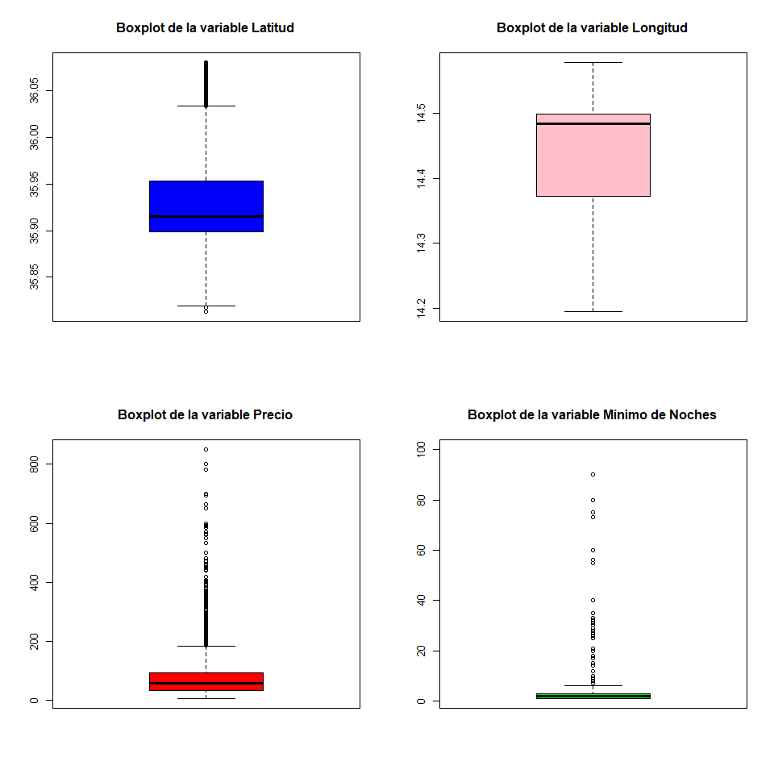

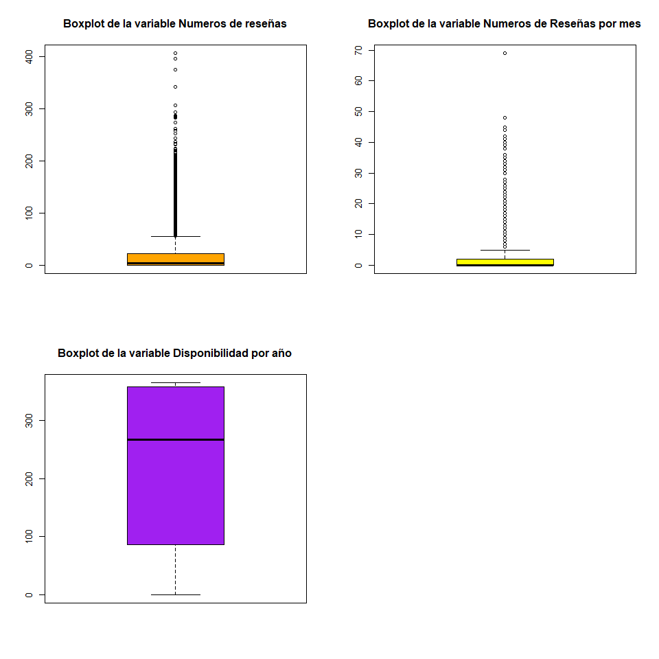

Histogramas de las variables numericas.

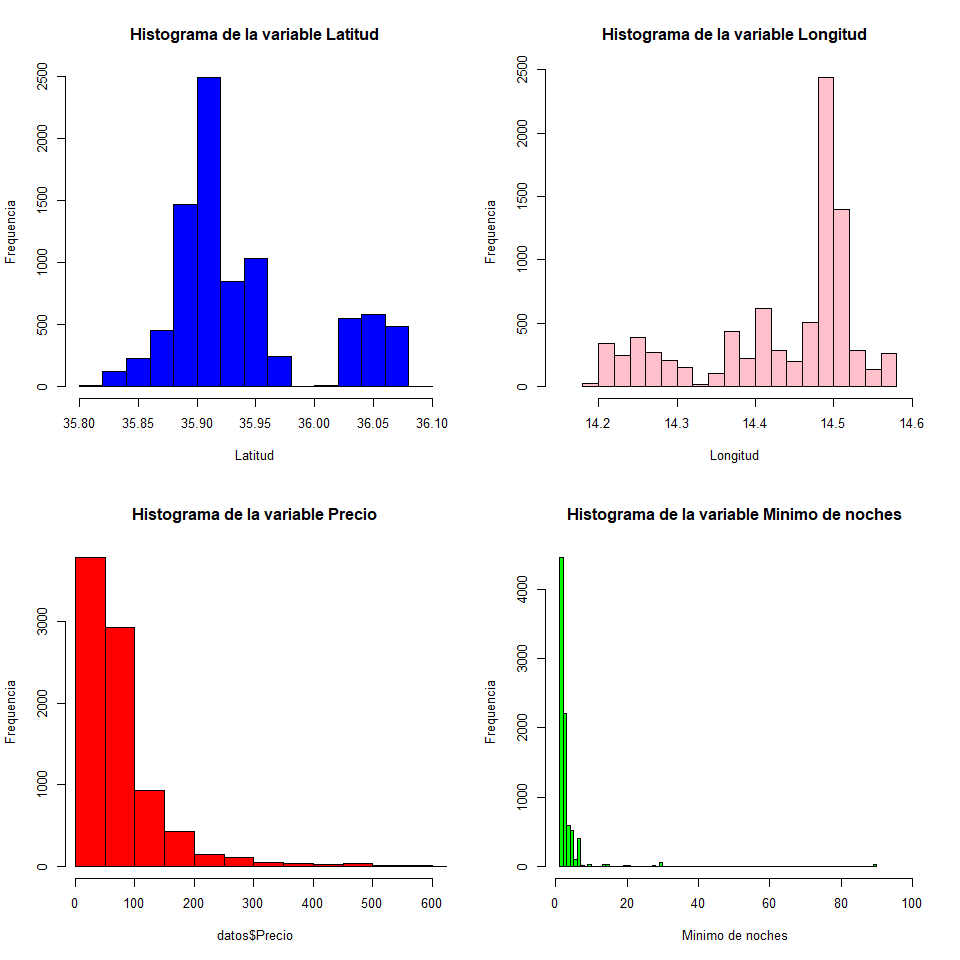

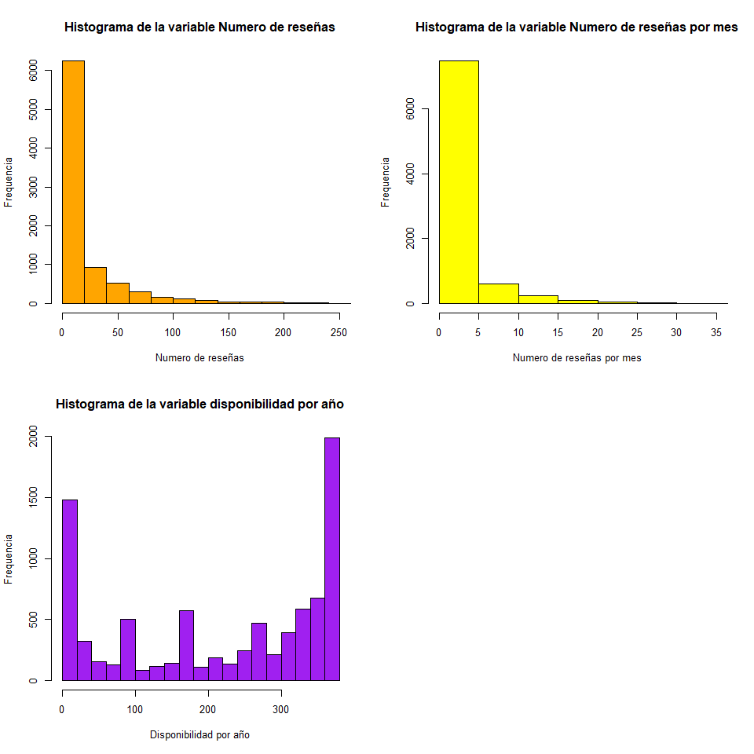

## **6. Pie chart de variables no numéricas.**

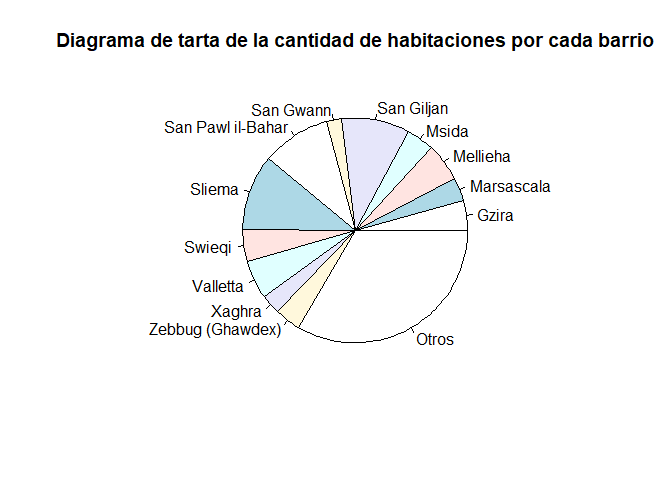

## **7. Valor medio de alguna de las variables numéricas según el barrio.**

```
     Santa Lucija            Mtarfa             Qormi         San Gwann
         24.00000          27.20000          36.31818          37.90426
             Safi             Paola            Kirkop        Birkirkara
         38.28571          39.66667          40.87500          44.91791
         Pembroke             Mosta             Msida             Gudja
         46.32051          49.38554          55.35588          55.44444
           Swieqi       Birzebbugia            Munxar             Marsa
         56.46036          58.26562          58.84138          59.50000
            Pieta            Attard San Pawl il-Bahar            Naxxar
         59.50000          61.64706          64.32614          67.46602
           Balzan             Gzira  Zebbug (Ghawdex)     Rabat (Malta)
         68.00000          68.37500          68.68910          69.32743
           Ghaxaq              Luqa        Marsascala           Xghajra
         70.45455          70.50000          72.21695          72.85714
            Birgu            Hamrun           Fontana        San Giljan
         73.06098          75.11111          76.59091          77.41155
            Mgarr            Qrendi            Sliema              Isla
         78.36923          78.61538          79.73102          79.93671
 Rabat (Victoria)           Kalkara          Floriana           Tarxien
         80.10345          81.09524          82.57480          85.00000
       Marsaxlokk            Bormla            Mqabba      Santa Venera
         85.54237          86.53175          86.66667          86.73913
      Ghajnsielem          Valletta          Siggiewi              Lija
         88.69524          88.80300          90.12000          90.54545
            Nadur             Iklin              Qala            Zabbar
         90.76860          93.62500          97.31884          97.82143
           Zejtun          Gharghur           Xewkija    Zebbug (Malta)
        103.36585         105.41176         111.30769         113.10000
         Mellieha             Mdina             Gharb            Xaghra
        114.67965         116.30769         118.09402         121.40161
           Kercem       San Lawrenz            Dingli            Sannat
        127.76190         127.96078         132.50000         132.84783
        Ta' Xbiex           Zurrieq            Ghasri             Fgura
        138.50000         148.56000         155.82500         163.57143
```

Valor medio de la variable Número de reseñas en base a los distintos barrios.

```
            Marsa            Dingli            Attard           Zurrieq
         1.333333          2.000000          5.764706          8.080000
           Swieqi         Ta' Xbiex            Zejtun         San Gwann
         8.219949          9.000000          9.000000          9.196809
         Pembroke            Ghasri            Naxxar          Gharghur
         9.538462          9.712500         10.184466         10.823529
      San Lawrenz        Birkirkara            Kercem             Msida
        11.019608         11.059701         11.142857         11.155882
          Fontana            Xaghra    Zebbug (Malta)            Sannat
        11.863636         12.485944         12.860000         12.978261
            Gharb             Mosta            Zabbar           Tarxien
        13.000000         13.457831         13.821429         14.781250
             Lija  Rabat (Victoria)          Mellieha      Santa Venera
        15.454545         15.577586         15.755411         15.913043
           Ghaxaq        Marsaxlokk        San Giljan          Siggiewi
        16.000000         16.338983         17.108303         17.440000
San Pawl il-Bahar           Xghajra       Ghajnsielem        Marsascala
        17.995204         18.095238         18.171429         18.254237
 Zebbug (Ghawdex)              Qala            Hamrun            Qrendi
        18.746795         18.913043         19.333333         19.692308
            Gzira             Qormi            Sliema             Nadur
        21.219444         21.590909         21.817787         21.892562
      Birzebbugia             Paola            Bormla            Mtarfa
        23.031250         23.619048         24.095238         25.000000
          Xewkija            Balzan     Rabat (Malta)            Munxar
        25.057692         25.473684         25.929204         26.041379
            Iklin           Kalkara             Mgarr             Pieta
        26.750000         26.904762         28.646154         28.912500
            Birgu          Valletta              Safi              Isla
        32.731707         36.901499         42.714286         43.708861
         Floriana              Luqa             Gudja             Fgura
        47.771654         51.000000         54.555556         54.571429
           Mqabba             Mdina            Kirkop      Santa Lucija
        61.666667         73.230769         78.875000        117.000000
```

Valor medio de la variable Disponibilidad por año en base a los distintos barrios.

```
          Zurrieq            Ghaxaq              Luqa      Santa Lucija
         166.0800          167.8182          175.1667          179.0000
           Balzan             Paola              Qala            Dingli
         180.7895          181.1429          182.0072          182.5000
        San Gwann             Fgura             Qormi             Pieta
         183.8085          185.5714          186.5682          190.5500
           Sliema          Pembroke        Birkirkara           Fontana
         191.1638          191.6026          192.0597          192.4545
     Santa Venera             Marsa             Mgarr             Gzira
         193.6522          195.8333          198.4000          199.1000
            Nadur              Lija     Rabat (Malta)          Siggiewi
         199.5950          200.0000          200.5752          200.9600
         Gharghur San Pawl il-Bahar        San Giljan            Zejtun
         204.2353          204.8237          205.3105          206.7805
           Mqabba            Swieqi            Naxxar             Msida
         207.3333          207.9974          209.2816          209.4500
           Hamrun            Xaghra          Floriana            Kercem
         212.3704          216.5020          217.7638          217.9683
 Rabat (Victoria)            Munxar       San Lawrenz            Ghasri
         218.2328          220.9379          223.5686          226.3750
      Ghajnsielem    Zebbug (Malta)            Kirkop        Marsascala
         229.6190          229.7400          229.8750          231.5390
            Mosta              Safi            Sannat            Bormla
         231.5422          233.0000          233.7174          234.7222
 Zebbug (Ghawdex)         Ta' Xbiex           Kalkara           Xghajra
         237.3269          241.1200          244.6667          247.0476
            Birgu       Birzebbugia           Xewkija          Mellieha
         248.9878          249.0312          250.4423          251.3074
           Qrendi             Gharb              Isla            Zabbar
         251.3846          252.5897          253.2658          254.2143
            Mdina          Valletta        Marsaxlokk           Tarxien
         260.4615          262.8201          274.2542          277.9375
            Iklin             Gudja            Attard            Mtarfa
         298.5000          309.1667          310.8235          316.0000
```

Valor medio de la variable Mínimo de noches en base a los distintos barrios.

```
           Kirkop      Santa Lucija              Luqa            Mtarfa
         1.000000          1.000000          1.583333          1.600000
            Gudja           Fontana             Paola              Safi
         1.666667          1.772727          1.904762          2.000000
           Hamrun            Qrendi           Xewkija  Rabat (Victoria)
         2.037037          2.153846          2.307692          2.318966
         Floriana            Kercem          Gharghur            Zabbar
         2.330709          2.349206          2.352941          2.357143
           Munxar           Tarxien            Zejtun          Valletta
         2.434483          2.437500          2.439024          2.464668
             Isla            Bormla              Lija        Marsaxlokk
         2.468354          2.515873          2.545455          2.559322
      San Lawrenz             Mgarr           Zurrieq             Mosta
         2.568627          2.584615          2.600000          2.614458
           Xaghra             Gharb            Mqabba           Xghajra
         2.658635          2.666667          2.666667          2.666667
         Pembroke            Ghasri       Ghajnsielem          Siggiewi
         2.756410          2.775000          2.790476          2.800000
            Birgu    Zebbug (Malta)             Mdina             Fgura
         2.817073          2.840000          2.846154          2.857143
             Qala             Qormi  Zebbug (Ghawdex)         Ta' Xbiex
         2.876812          2.886364          2.907051          3.180000
       San Giljan            Sliema           Kalkara     Rabat (Malta)
         3.225030          3.247289          3.285714          3.318584
            Marsa             Nadur San Pawl il-Bahar            Sannat
         3.333333          3.446281          3.484412          3.521739
            Pieta       Birzebbugia         San Gwann            Swieqi
         3.775000          3.812500          3.829787          3.867008
         Mellieha            Ghaxaq             Msida        Marsascala
         3.904762          4.090909          4.200000          4.216949
       Birkirkara            Dingli             Gzira            Naxxar
         4.425373          4.500000          4.505556          4.912621
           Balzan             Iklin      Santa Venera            Attard
         5.315789          6.625000          7.608696          7.823529
```

## **8. Boxplot de la variable precio, para los 5 barrios más caros y los 5 barrios más baratos.**

[figure not shown]

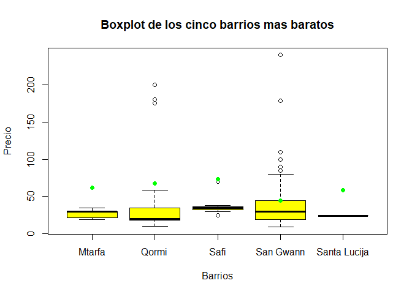

## **9. Diagramas de dispersión de 4 variables numéricas 2 a 2, con un color para cada Vecindario.**

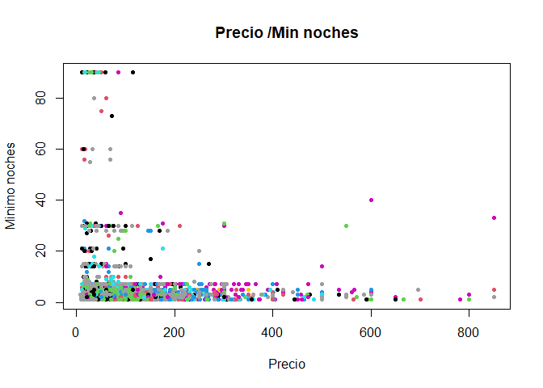

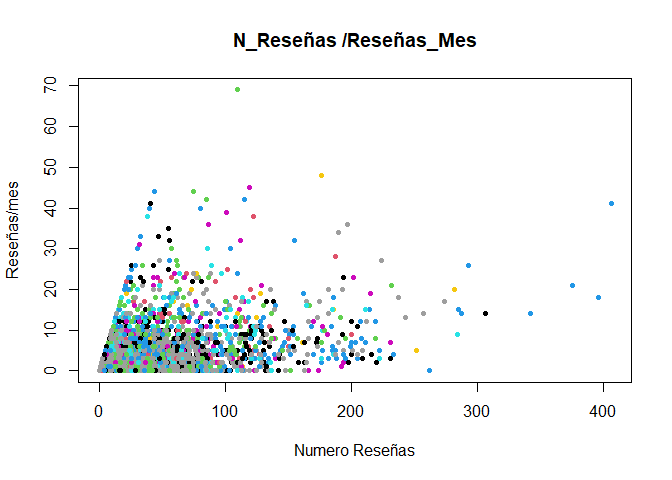

## **10. Coeficientes de correlación 2 a 2 apartado anterior.**

```
[1] 0.005161337
```

```
[1] 0.5037265
```

## **11. Con 2 variables numéricas, organizar sus valores en un máximo de 5 intervalos con ala función cut.**

```
(6.16,176]  (176,344]  (344,513]  (513,681]  (681,851]
      7844        509        103         22          8
```

```
(-0.406,81.2]    (81.2,162]     (162,244]     (244,325]     (325,406]
         7994           387            91            10             4
```

## **12. A partir de los datos en intervalos obtenidos en el apartado anterior construid una tabla de contingencia de las dos variables y dibuja el diagrama de mosaico asociado a la mesa.**

```
             (-0.406,81.2] (81.2,162] (162,244] (244,325] (325,406]
  (6.16,176]          7361        380        89        10         4
  (176,344]            502          6         1         0         0
  (344,513]            102          1         0         0         0
  (513,681]             21          0         1         0         0
  (681,851]              8          0         0         0         0
```

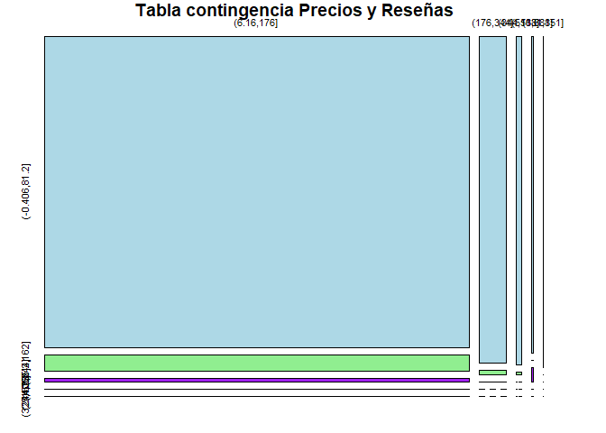